# Multi-scale molecular modeling

## Revealing the Entropic Effect: Computational Insights into the PchB Enzymatic Reaction

**Introduction**:

The role of entropy in enzymatic reactions has long been a central research question. In a study titled "Understanding the entropic effect in chorismate mutase reaction catalyzed by isochorismate-pyruvate lyase from Pseudomonas aeruginosa (PchB)," we employed computational methods to evaluate the entropic effect in the PchB-catalyzed chorismate mutase reaction. Through quantum mechanics/molecular mechanics molecular dynamics simulations, the study determined for the first time that the PchB-catalyzed reaction is entropy-driven. Additionally, the study revealed an additional entropic penalty arising from the substrate preorganization process, leading to a significant apparent entropic effect in the reaction. These findings provide an explanation for the large measured entropic effect in experiments and confirm the entropy-driven nature of the PchB-catalyzed chorismate mutase reaction.

**Methods and Problem**:

To address the role of entropy in enzymatic reactions, the research team utilized computational methods, specifically molecular dynamics simulations, to evaluate the entropic effect in the PchB-catalyzed chorismate mutase reaction. By conducting calculations on a sufficient number of samples, they determined for the first time that the reaction is entropy-driven. Furthermore, the study identified an additional entropic penalty during the substrate preorganization process, contributing to the observed significant entropic effect. The primary problem addressed in this study was to explain the large measured entropic effect in experiments and validate the entropy-driven nature of the PchB-catalyzed chorismate mutase reaction.

**Conclusions**:

Through the application of computational methods, this study successfully revealed the entropic effect in the PchB-catalyzed chorismate mutase reaction. The results indicate that the reaction is entropy-driven, with the additional entropic penalty during substrate preorganization playing a crucial role in the apparent entropic effect. The findings not only provide an explanation for the observed entropic effect in experiments but also offer valuable insights for future enzyme design projects. By better understanding the entropic effect in enzymatic reactions, we can provide guidance for rational enzyme design and protein engineering. This holds significant implications for developing efficient enzyme-catalyzed reactions and addressing biocatalysis challenges in the real world

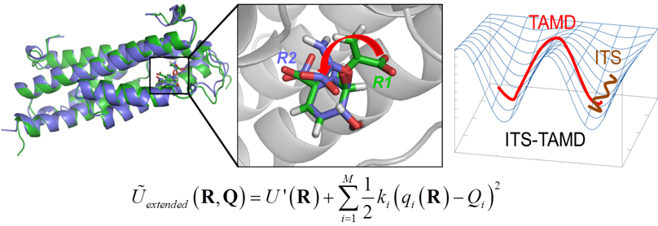

**简介**：

在酶催化反应中，熵的作用一直是研究的中心问题之一。《Understanding the entropic effect in chorismate mutase reaction catalyzed by isochorismate-pyruvate lyase from Pseudomonas aeruginosa (PchB)》的研究通过计算方法首次评估了PchB酶催化的chorismate mutase反应中的熵效应。通过量子力学/分子力学分子动力学模拟，确定了PchB酶催化的chorismate mutase反应是由熵驱动的。此外，还揭示了底物预组织过程中的额外熵惩罚，这导致了反应中明显的表观熵效应。这项研究的结果为解释实验中测量到的大幅熵效应提供了解释，并确认了PchB酶催化的chorismate mutase反应是由熵驱动的。

**方法和问题**：

为了解决酶催化反应中熵的作用，研究团队采用了计算方法进行分子动力学模拟，以评估PchB酶催化的chorismate mutase反应中的熵效应。通过对足够数量的样本进行计算，他们首次确定了该反应是由熵驱动的。此外，研究还发现底物预组织过程中存在额外的熵惩罚，这导致了实验中观察到的明显熵效应。这项研究的主要问题是解释实验中观察到的大幅熵效应，并验证PchB酶催化的chorismate mutase反应是由熵驱动的。

**结论**：

通过计算方法的应用，这项研究成功地揭示了PchB酶催化的chorismate mutase反应中的熵效应。研究结果表明，该反应是由熵驱动的，并且底物预组织过程中的额外熵惩罚对反应中的表观熵效应起到了重要作用。这项研究的发现不仅为实验中观察到的熵效应提供了解释，还为未来的酶设计项目提供了有用的线索。通过更好地理解酶催化反应中的熵效应，我们可以为酶的合理设计和蛋白质工程提供更多的指导。这对于开发高效的酶催化反应和解决现实世界中的生物催化问题具有重要意义。

Return to Research.